# Pantaleo exploratory analysis - TFH146

Kushal Dey, Valentin Voillet

7/17/2017

# 1 Data Loading & Description

Briefly, paired PBMCs (Peripheral blood mononuclear cells) and LN (Lymph Node) from patients were stained and sorted for TFH (T Follicular Helper) and Live cells. There are three HIV+ CP off treatment and three HIV- patients.

Per patient, per sample, two Seq-Well arrays were processed. *NB: each patient has the following processed array conditions: LN TFH, LN Live, PBMC TFH, & PBMC Live.*

Here - we have four arrays from one HIV- CP patient.

**Obj: Re-perform the analysis // Look at the data.**

Live cells

TFH cells (LN + PBMC)

```r
TFH_LN_UMI <- read.table('TFH146/TFH Sorted/LN/reads.TFH146_TFH_LN_S1_R1_001.fastq_bq10_star_corrected.umi.dge.txt.gz', header = TRUE, row.names = 1)
TFH_LN_reads <- read.table('TFH146/TFH Sorted/LN/reads.TFH146_TFH_LN_S1_R1_001.fastq_bq10_star_corrected.reads.dge.txt.gz', header = TRUE, row.names = 1)
TFH_LN_UMI_summary <- read.table('TFH146/TFH Sorted/LN/reads.TFH146_TFH_LN_S1_R1_001.fastq_bq10_star_corrected.umi.dge.summary.txt', header = TRUE, row.names = 1)
TFH_LN_reads_summary <- read.table('TFH146/TFH Sorted/LN/reads.TFH146_TFH_LN_S1_R1_001.fastq_bq10_star_corrected.reads.dge.summary.txt', header = TRUE, row.names = 1)
#- First filtering - remove cells with less than 10 genes
TFH_LN_UMI <- TFH_LN_UMI[, rownames(TFH_LN_reads_summary)[which(TFH_LN_reads_summary$NUM_GENES > 10)]]
TFH_LN_reads <- TFH_LN_reads[, rownames(TFH_LN_reads_summary)[which(TFH_LN_reads_summary$NUM_GENES > 10)]]
TFH_LN_UMI_summary <- TFH_LN_UMI_summary[colnames(TFH_LN_UMI), ]
TFH_LN_reads_summary <- TFH_LN_reads_summary[colnames(TFH_LN_reads), ]

##- PBMC
TFH_PBMC_UMI <- read.table('TFH146/TFH Sorted/PBMC/reads.TFH146_TFH_PBMC_S2_R1_001.fastq_bq10_star_corrected.umi.dge.txt.gz', header = TRUE, row.names = 1)
TFH_PBMC_reads <- read.table('TFH146/TFH Sorted/PBMC/reads.TFH146_TFH_PBMC_S2_R1_001.fastq_bq10_star_corrected.reads.dge.txt.gz', header = TRUE, row.names = 1)
TFH_PBMC_UMI_summary <- read.table('TFH146/TFH Sorted/PBMC/reads.TFH146_TFH_PBMC_S2_R1_001.fastq_bq10_star_corrected.umi.dge.summary.txt', header = TRUE, row.names = 1)
TFH_PBMC_reads_summary <- read.table('TFH146/TFH Sorted/PBMC/reads.TFH146_TFH_PBMC_S2_R1_001.fastq_bq10_star_corrected.reads.dge.summary.txt', header = TRUE, row.names = 1)
#- First filtering - remove cells with less than 10 genes
TFH_PBMC_UMI <- TFH_PBMC_UMI[, rownames(TFH_PBMC_reads_summary)[which(TFH_PBMC_reads_summary$NUM_GENES > 10)]]
TFH_PBMC_reads <- TFH_PBMC_reads[, rownames(TFH_PBMC_reads_summary)[which(TFH_PBMC_reads_summary$NUM_GENES > 10)]]
TFH_PBMC_UMI_summary <- TFH_PBMC_UMI_summary[colnames(TFH_PBMC_UMI), ]
TFH_PBMC_reads_summary <- TFH_PBMC_reads_summary[colnames(TFH_PBMC_reads), ]
```

# 2 Live Cells

## 2.1 Raw Count

Let’s look at the distribution of UMIs and nb. of detected genes in both LN and PBMC samples for Live Cells.

*NB: We do not have information about read distribution.*

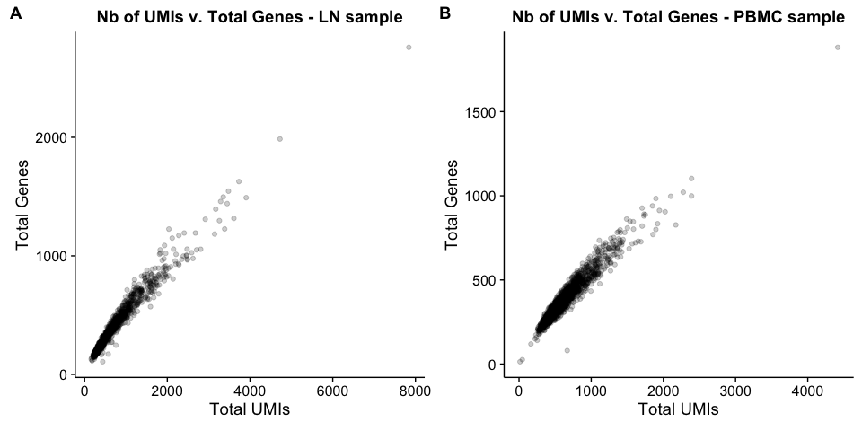

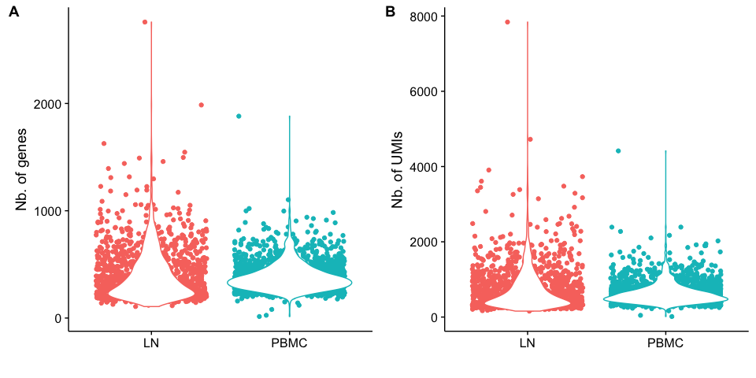

Close nb. of UMIs and detected genes are observed in bith LN and PBMC samples from Live Cells.  
## QC and Filtering

The next step is then to perform quality control and filtering (remove cells with few reads/UMIs or genes, etc.).

The threshold that Sam used was **750 UMIs** and **400 genes** (see *Slides for Pantaleo 053017.ppt* file - HIV+ patient). So, let’s use the same here, and also remove genes with less than one UMI count.

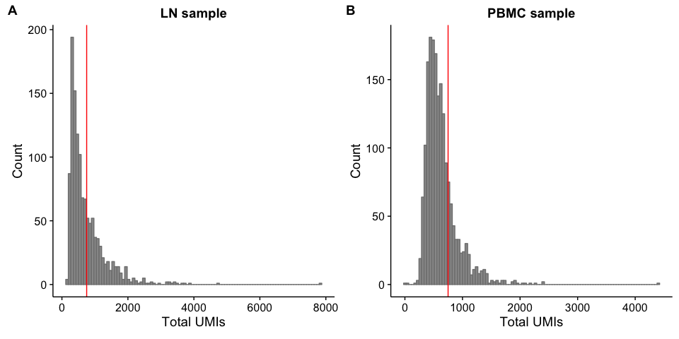

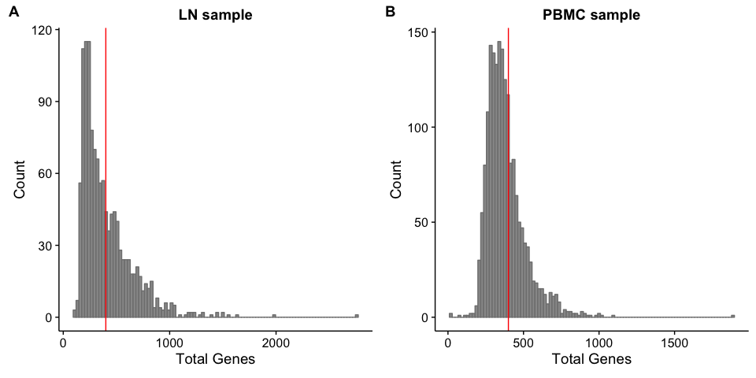

```r
###--- Filtering datasets and merging
#- LN
identical(colnames(LiveCells_LN_UMI), rownames(LiveCells_LN_UMI_summary)) # TRUE
```

```
## [1] TRUE
```

```r
LiveCells_LN_UMI_filtered <- LiveCells_LN_UMI[, which(LiveCells_LN_UMI_summary$NUM_GENES >= 400 & LiveCells_LN_UMI_summary$NUM_TRANSCRIPTS >= 750)] # 417 cells
LiveCells_LN_UMI_filtered <- LiveCells_LN_UMI_filtered[which(apply(LiveCells_LN_UMI_filtered, 1, sum) != 0), ] # 14,946 genes and 417 cells
#- PBMC
identical(colnames(LiveCells_PBMC_UMI), rownames(LiveCells_PBMC_UMI_summary)) # TRUE
```

```
## [1] TRUE
```

```r
LiveCells_PBMC_UMI_filtered <- LiveCells_PBMC_UMI[, which(LiveCells_PBMC_UMI_summary$NUM_GENES >= 400 & LiveCells_PBMC_UMI_summary$NUM_TRANSCRIPTS >= 750)] # 409 cells
LiveCells_PBMC_UMI_filtered <- LiveCells_PBMC_UMI_filtered[which(apply(LiveCells_PBMC_UMI_filtered, 1, sum) != 0), ] # 12,391 genes and 409 cells
#- Merging
LiveCells_UMI <- rbind.fill(as.data.frame(t(LiveCells_LN_UMI_filtered)), as.data.frame(t(LiveCells_PBMC_UMI_filtered)))
rownames(LiveCells_UMI) <- c(paste(colnames(LiveCells_LN_UMI_filtered), 'LN', sep = '_'), paste(colnames(LiveCells_PBMC_UMI_filtered), 'PBMC', sep = '_'))
dim(LiveCells_UMI) # 826 cells and 16,230 genes
```

```
## [1]   826 16230
```

```r
length(unique(c(rownames(LiveCells_LN_UMI_filtered), rownames(LiveCells_PBMC_UMI_filtered)))) # 16,230 genes
```

```
## [1] 16230
```

```r
LiveCells_UMI[is.na(LiveCells_UMI)] <- 0 # NAs - replace NA by 0
LiveCells_UMI <- as.data.frame(t(LiveCells_UMI))
```

```r
LiveCells_fac <- c(rep("Live_LN", dim(LiveCells_LN_UMI_filtered)[2]),
                   rep("Live_PBMC", dim(LiveCells_PBMC_UMI_filtered)[2]))
```

Apply CountClust on the Live cells.

```r
counts <- t(LiveCells_UMI)
```

## 2.2 Removing ribosomal, mitochondrial and small RNA genes

```r
idx <- which(!is.na(match(substring(colnames(counts), 1, 2), c("RP", "MT", "RN"))))
counts2 <- counts[, -idx]
```

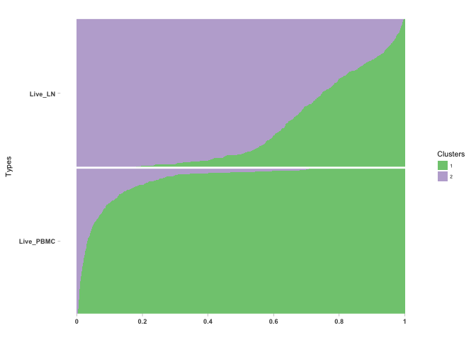

```r
topic_clus_list <- get(load("TFH146/CountClust_Models_filtered.rda"))
PlotCountClust(topic_clus_list[[2]], LiveCells_fac)
```

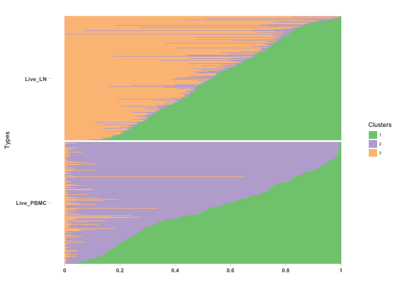

```r
PlotCountClust(topic_clus_list[[3]], LiveCells_fac)
```

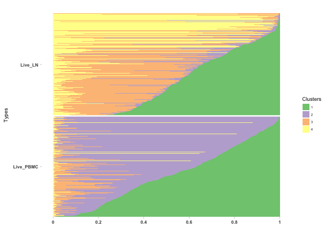

```r
PlotCountClust(topic_clus_list[[4]], LiveCells_fac)
```

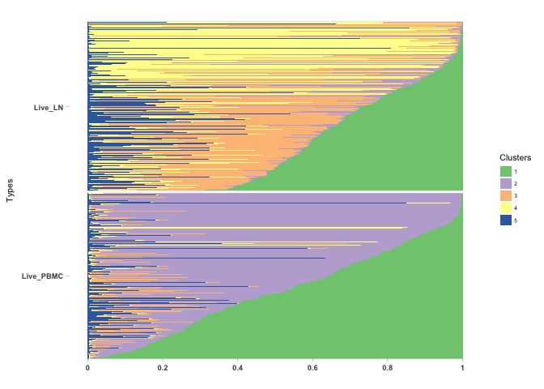

```r
PlotCountClust(topic_clus_list[[5]],  LiveCells_fac)
```

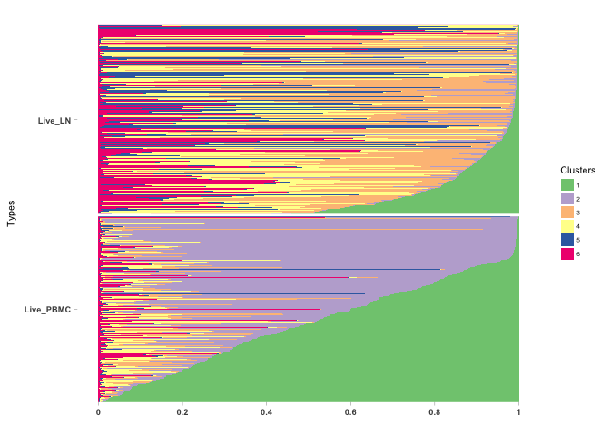

```r
PlotCountClust(topic_clus_list[[6]],  LiveCells_fac)
```

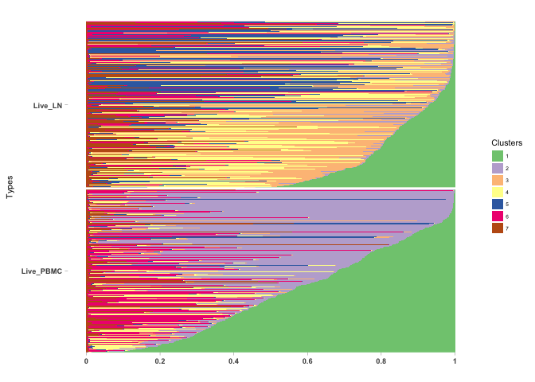

```r
PlotCountClust(topic_clus_list[[7]],  LiveCells_fac)
```

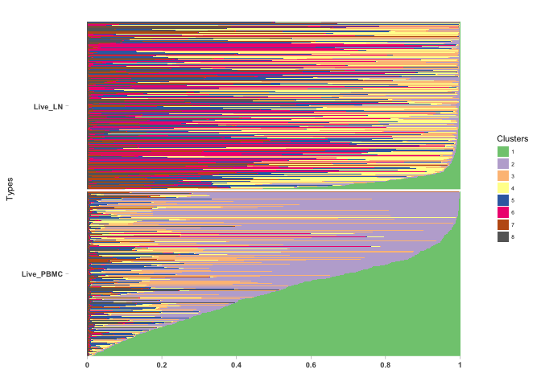

```r
PlotCountClust(topic_clus_list[[8]],  LiveCells_fac)
```

```r
indices <- ExtractTopFeatures(topic_clus_list[[4]]$theta, top_features = 100, method = "poisson", options = "max")
```

```r
imp_genes <- apply(indices, 1, function(x) return(colnames(counts2)[x]))
for(m in 1:dim(imp_genes)[2]){
  write.table(imp_genes[,m], file = paste0("gene_names_", m, ".txt"), quote = FALSE, row.names = FALSE, col.names = FALSE)
}
```

### 2.2.1 top genes - Cluster 1, K = 4

```r
out <- mygene::queryMany(imp_genes[1:50,1],  scopes="symbol", fields=c("name", "summary"), species="human");
```

```
## Finished
## Pass returnall=TRUE to return lists of duplicate or missing query terms.
```

```r
cbind.data.frame(out$name)
```

```
##                                                                    out$name
## 1                                                    interleukin 7 receptor
## 2                                                            interleukin 32
## 3                                           S100 calcium binding protein A6
## 4                                           cytochrome c oxidase subunit 6C
## 5                                              GTPase, IMAP family member 7
## 6                                                              CD2 molecule
## 7                                  NDUFA4, mitochondrial complex associated
## 8                                                   Y-box binding protein 1
## 9                                        signal sequence receptor subunit 4
## 10                                           C-C motif chemokine receptor 7
## 11                                                               selectin L
## 12                                           proteasome activator subunit 1
## 13                                  RNA binding motif (RNP1, RRM) protein 3
## 14                                                               galectin 1
```

[output cut: 36 more lines]

### 2.2.2 top genes - Cluster 2, K = 4

```r
out <- mygene::queryMany(imp_genes[1:50,2],  scopes="symbol", fields=c("name", "summary"), species="human");
```

```
## Finished
## Pass returnall=TRUE to return lists of duplicate or missing query terms.
```

```r
cbind.data.frame(out$name)
```

```
##                                                       out$name
## 1                                 C-C motif chemokine ligand 5
## 2                                                   granulysin
## 3                                                   granzyme B
## 4                        natural killer cell granule protein 7
## 5                                    C-X9-C motif containing 1
## 6                                         beta-2-microglobulin
## 7                                         beta-2-microglobulin
## 8                                         beta-2-microglobulin
## 9                                                   cystatin F
## 10                         killer cell lectin like receptor D1
## 11                                                  perforin 1
## 12                     inhibitor of DNA binding 2, HLH protein
## 13                                                  granzyme H
## 14                      C-type lectin domain family 2 member B
```

[output cut: 39 more lines]

### 2.2.3 top genes - Cluster 3, K = 4

```r
out <- mygene::queryMany(imp_genes[1:50,3],  scopes="symbol", fields=c("name", "summary"), species="human");
```

```
## Finished
## Pass returnall=TRUE to return lists of duplicate or missing query terms.
```

```r
cbind.data.frame(out$name)
```

```
##                                                                       out$name
## 1                       Metastasis associated lung adenocarcinoma transcript 1
## 2  metastasis associated lung adenocarcinoma transcript 1 (non-protein coding)
## 3                                heat shock protein family A (Hsp70) member 1B
## 4                                heat shock protein family A (Hsp70) member 1A
## 5                                                                vault RNA 1-3
## 6                                                  TBC1 domain family member 1
## 7                             DnaJ heat shock protein family (Hsp40) member B1
## 8                                                                         <NA>
## 9                                              small nucleolar RNA, C/D box 89
## 10                                                                        <NA>
## 11                       Jun proto-oncogene, AP-1 transcription factor subunit
## 12                                         regulator of G protein signaling 10
## 13                                                                       titin
## 14                                heat shock protein family A (Hsp70) member 6
```

[output cut: 41 more lines]

### 2.2.4 top genes - Cluster 4, K = 4

```r
out <- mygene::queryMany(imp_genes[1:50,4],  scopes="symbol", fields=c("name", "summary"), species="human");
```

```
## Finished
## Pass returnall=TRUE to return lists of duplicate or missing query terms.
```

```r
cbind.data.frame(out$name)
```

```
##                                                  out$name
## 1    major histocompatibility complex, class II, DR alpha
## 2                          membrane spanning 4-domains A1
## 3                                           vault RNA 1-1
## 4                                        lymphotoxin beta
## 5                           immunoglobulin kappa constant
## 6                           immunoglobulin kappa constant
## 7                                                    <NA>
## 8                   immunoglobulin heavy constant alpha 1
## 9                   immunoglobulin heavy constant alpha 1
## 10                  immunoglobulin heavy constant alpha 1
## 11                                          CD74 molecule
## 12         B-cell scaffold protein with ankyrin repeats 1
## 13 major histocompatibility complex, class II, DQ alpha 1
## 14  major histocompatibility complex, class II, DQ beta 1
```

[output cut: 47 more lines]

## 2.3 Expression profile validation

We validate the expression profile of some of the genes that were picked up by the clustering method. We first perform a hard assignment of each single cell to the cluster with the highest grade of membership. We also pool in the metadata on whether that cell is from the Lymph node or it is PBMC.

```r
topic_clus_list <- get(load("TFH146/CountClust_Models_filtered.rda"))
indices <- ExtractTopFeatures(topic_clus_list[[4]]$theta, top_features = 100, method = "poisson", options = "max")
fac1 <- apply(topic_clus_list[[4]]$omega, 1, function(x) return(which.max(x)))
conditions <- paste0(LiveCells_fac, "|", paste0("Clus-", fac1))
```

### 2.3.1 First cluster genes, K = 4

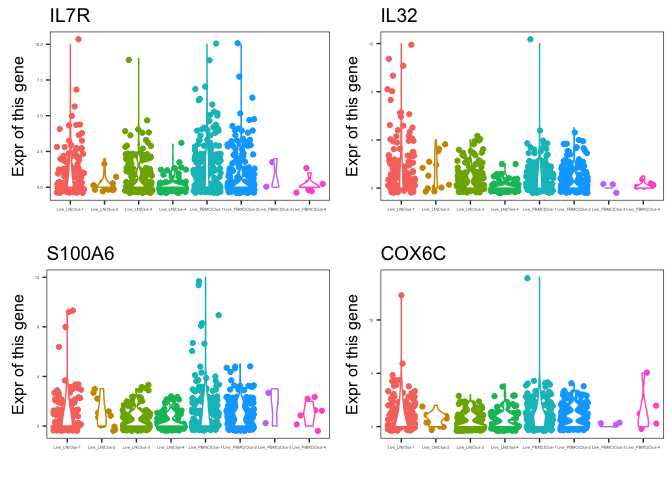

```r
data_ggplot <- as.data.frame(counts2[, indices[1,c(1, 2, 3, 4)]])
colnames(data_ggplot) <- c("Expr1", "Expr2", "Expr3", "Expr4")
data_ggplot$Condition <- conditions
plot1 <- ggplot(data = data_ggplot) + geom_jitter(aes(x = Condition, y = Expr1, color = Condition)) + geom_violin(aes(x = Condition, y = Expr1, color = Condition)) + labs(x = '', y = 'Expr of this gene') + guides(color = 'none') + theme(axis.text.x = element_text(size=3)) + theme(axis.text.y = element_text(size=3)) + ggtitle(paste0(imp_genes[1,1]))
plot2 <- ggplot(data = data_ggplot) + geom_jitter(aes(x = Condition, y = Expr2, color = Condition)) + geom_violin(aes(x = Condition, y = Expr2, color = Condition)) + labs(x = '', y = 'Expr of this gene') + guides(color = 'none') + theme(axis.text.x = element_text(size=3)) + theme(axis.text.y = element_text(size=3)) + ggtitle(paste0(imp_genes[2,1]))
plot3 <- ggplot(data = data_ggplot) + geom_jitter(aes(x = Condition, y = Expr3, color = Condition)) + geom_violin(aes(x = Condition, y = Expr3, color = Condition)) + labs(x = '', y = 'Expr of this gene') + guides(color = 'none') + theme(axis.text.x = element_text(size=3)) + theme(axis.text.y = element_text(size=3)) + ggtitle(paste0(imp_genes[3,1]))
plot4 <- ggplot(data = data_ggplot) + geom_jitter(aes(x = Condition, y = Expr4, color = Condition)) + geom_violin(aes(x = Condition, y = Expr4, color = Condition)) + labs(x = '', y = 'Expr of this gene') + guides(color = 'none') + theme(axis.text.x = element_text(size=3)) + theme(axis.text.y = element_text(size=3)) + ggtitle(paste0(imp_genes[4,1]))
plot_grid(plot1, plot2, plot3, plot4, ncol = 2, align = 'h')
```

### 2.3.2 Second cluster genes, K = 4

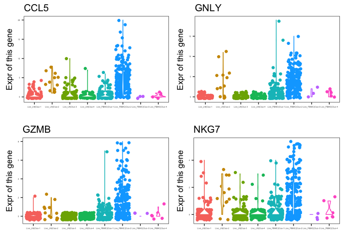

```r
data_ggplot <- as.data.frame(counts2[, indices[2,c(1, 2, 3, 4)]])
colnames(data_ggplot) <- c("Expr1", "Expr2", "Expr3", "Expr4")
data_ggplot$Condition <- conditions
plot1 <- ggplot(data = data_ggplot) + geom_jitter(aes(x = Condition, y = Expr1, color = Condition)) + geom_violin(aes(x = Condition, y = Expr1, color = Condition)) + labs(x = '', y = 'Expr of this gene') + guides(color = 'none') + theme(axis.text.x = element_text(size=3)) + theme(axis.text.y = element_text(size=3)) + ggtitle(paste0(imp_genes[1,2]))
plot2 <- ggplot(data = data_ggplot) + geom_jitter(aes(x = Condition, y = Expr2, color = Condition)) + geom_violin(aes(x = Condition, y = Expr2, color = Condition)) + labs(x = '', y = 'Expr of this gene') + guides(color = 'none') + theme(axis.text.x = element_text(size=3)) + theme(axis.text.y = element_text(size=3)) + ggtitle(paste0(imp_genes[2,2]))
plot3 <- ggplot(data = data_ggplot) + geom_jitter(aes(x = Condition, y = Expr3, color = Condition)) + geom_violin(aes(x = Condition, y = Expr3, color = Condition)) + labs(x = '', y = 'Expr of this gene') + guides(color = 'none') + theme(axis.text.x = element_text(size=3)) + theme(axis.text.y = element_text(size=3)) + ggtitle(paste0(imp_genes[3,2]))
plot4 <- ggplot(data = data_ggplot) + geom_jitter(aes(x = Condition, y = Expr4, color = Condition)) + geom_violin(aes(x = Condition, y = Expr4, color = Condition)) + labs(x = '', y = 'Expr of this gene') + guides(color = 'none') + theme(axis.text.x = element_text(size=3)) + theme(axis.text.y = element_text(size=3)) + ggtitle(paste0(imp_genes[4,2]))
plot_grid(plot1, plot2, plot3, plot4, ncol = 2, align = 'h')
```

### 2.3.3 Third cluster genes, K = 4

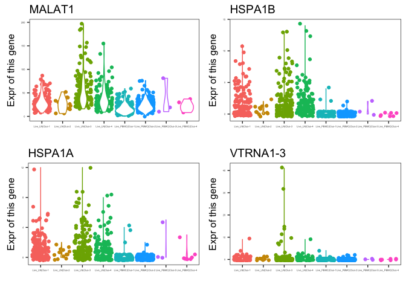

```r
data_ggplot <- as.data.frame(counts2[, indices[3,c(1, 2, 3, 4)]])
colnames(data_ggplot) <- c("Expr1", "Expr2", "Expr3", "Expr4")
data_ggplot$Condition <- conditions
plot1 <- ggplot(data = data_ggplot) + geom_jitter(aes(x = Condition, y = Expr1, color = Condition)) + geom_violin(aes(x = Condition, y = Expr1, color = Condition)) + labs(x = '', y = 'Expr of this gene') + guides(color = 'none') + theme(axis.text.x = element_text(size=3)) + theme(axis.text.y = element_text(size=3)) + ggtitle(paste0(imp_genes[1,3]))
plot2 <- ggplot(data = data_ggplot) + geom_jitter(aes(x = Condition, y = Expr2, color = Condition)) + geom_violin(aes(x = Condition, y = Expr2, color = Condition)) + labs(x = '', y = 'Expr of this gene') + guides(color = 'none') + theme(axis.text.x = element_text(size=3)) + theme(axis.text.y = element_text(size=3)) + ggtitle(paste0(imp_genes[2,3]))
plot3 <- ggplot(data = data_ggplot) + geom_jitter(aes(x = Condition, y = Expr3, color = Condition)) + geom_violin(aes(x = Condition, y = Expr3, color = Condition)) + labs(x = '', y = 'Expr of this gene') + guides(color = 'none') + theme(axis.text.x = element_text(size=3)) + theme(axis.text.y = element_text(size=3)) + ggtitle(paste0(imp_genes[3,3]))
plot4 <- ggplot(data = data_ggplot) + geom_jitter(aes(x = Condition, y = Expr4, color = Condition)) + geom_violin(aes(x = Condition, y = Expr4, color = Condition)) + labs(x = '', y = 'Expr of this gene') + guides(color = 'none') + theme(axis.text.x = element_text(size=3)) + theme(axis.text.y = element_text(size=3)) + ggtitle(paste0(imp_genes[4,3]))
plot_grid(plot1, plot2, plot3, plot4, ncol = 2, align = 'h')
```

### 2.3.4 Fourth cluster genes, K = 4

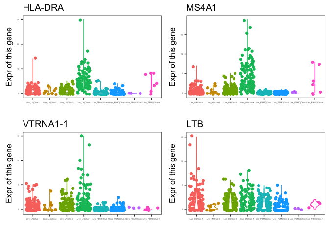

```r
data_ggplot <- as.data.frame(counts2[, indices[4,c(1, 2, 3, 4)]])
colnames(data_ggplot) <- c("Expr1", "Expr2", "Expr3", "Expr4")
data_ggplot$Condition <- conditions
plot1 <- ggplot(data = data_ggplot) + geom_jitter(aes(x = Condition, y = Expr1, color = Condition)) + geom_violin(aes(x = Condition, y = Expr1, color = Condition)) + labs(x = '', y = 'Expr of this gene') + guides(color = 'none') + theme(axis.text.x = element_text(size=3)) + theme(axis.text.y = element_text(size=3)) + ggtitle(paste0(imp_genes[1,4]))
plot2 <- ggplot(data = data_ggplot) + geom_jitter(aes(x = Condition, y = Expr2, color = Condition)) + geom_violin(aes(x = Condition, y = Expr2, color = Condition)) + labs(x = '', y = 'Expr of this gene') + guides(color = 'none') + theme(axis.text.x = element_text(size=3)) + theme(axis.text.y = element_text(size=3)) + ggtitle(paste0(imp_genes[2,4]))
plot3 <- ggplot(data = data_ggplot) + geom_jitter(aes(x = Condition, y = Expr3, color = Condition)) + geom_violin(aes(x = Condition, y = Expr3, color = Condition)) + labs(x = '', y = 'Expr of this gene') + guides(color = 'none') + theme(axis.text.x = element_text(size=3)) + theme(axis.text.y = element_text(size=3)) + ggtitle(paste0(imp_genes[3,4]))
plot4 <- ggplot(data = data_ggplot) + geom_jitter(aes(x = Condition, y = Expr4, color = Condition)) + geom_violin(aes(x = Condition, y = Expr4, color = Condition)) + labs(x = '', y = 'Expr of this gene') + guides(color = 'none') + theme(axis.text.x = element_text(size=3)) + theme(axis.text.y = element_text(size=3)) + ggtitle(paste0(imp_genes[4,4]))
plot_grid(plot1, plot2, plot3, plot4, ncol = 2, align = 'h')
```